# RMS Titanic Survival Prediction

Sofia Ward

2024-10-25

# Introduction

The aim of this project is to build a machine learning model that can predict whether or not a passenger aboard the titanic will survive depending on personal attributes. We will be using data from Github, and implementing multiple techniques to yield the most accurate model for this binary classification problem. Let’s go for it!

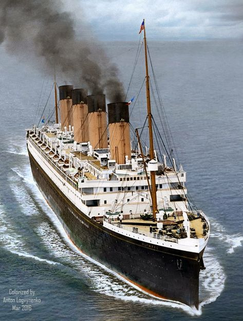

### About the Titanic

The Titanic, officially named the RMS Titanic, was a British passenger liner that tragically sank on April 15, 1912, during its maiden voyage from Southampton, England, to New York City. Built by the White Star Line, it was the largest and most luxurious ship of its time, famously deemed “unsinkable” due to its advanced engineering and safety features. However, the Titanic struck an iceberg in the North Atlantic, leading to the loss of over 1,500 lives out of the approximately 2,224 passengers and crew on board.

Our data composes of passengers that boarded the titanic, each with attributes such as passenger name, age, sex, class, fare, etc. We also know which passengers survived the disaster, which we will use to build a survival prediction model!

### The Data

Our data is not a historical record, it is derived from detailed records of passengers, crew, and events surrounding the sinking of the Titanic.

The main sources include:

- **Passenger and Crew Manifests**: These were official documents listing the passengers and crew on board, including ticket classes, ages, and names.
- **Survivor Records**: Data on who survived was compiled from rescue records by the RMS Carpathia and inquiries conducted by the British and U.S. governments.
- **Insurance and Compensation Claims**: Additional data on passengers’ ages, professions, and families was retrieved from legal documents filed after the disaster.

Sources like Github and Kaggle have refined and organized datasets or public modeling analysis, we will be using Github’s: https://github.com/datasciencedojo/datasets/blob/master/titanic.csv

### Project Roadmap

[figure not shown]

Jack + Rose

Now that we know the background and importance of our model, let’s discuss how we are going to build it throughout this project. There will need to be some initial data manipulation and cleaning, and then we will perform some exploratory data analysis to get a further detailed idea on our variables and aim. Our goal is to use other predictor variables to predict a binary class “survivors”, which will be our response variable. We will then perform a training/test split on our data, make a recipe, and set folds for the 10-fold cross validation we will implement. **Logistic Regression, Lasso, Random Forest, and K-Nearest Neighbor** models will be all used to model the training data when we finish the setup. Whichever model performs the strongest, we will then fit to our testing data set and analyze how effective our model can truly be!

# Exploratory Data Analysis

Let’s load in the data and take a peak.

```r
tidymodels_prefer()

titanic <- read_csv(file = "data/titanic.csv")

head(titanic)
```

| passenger_id | survived | pclass | name | sex | age | sib_sp | parch | ticket | fare | cabin | embarked |
| --- | --- | --- | --- | --- | --- | --- | --- | --- | --- | --- | --- |
| 1 | No | 3 | Braund, Mr. Owen Harris | male | 22 | 1 | 0 | A/5 21171 | 7.2500 | NA | S |
| 2 | Yes | 1 | Cumings, Mrs. John Bradley (Florence Briggs Thayer) | female | 38 | 1 | 0 | PC 17599 | 71.2833 | C85 | C |
| 3 | Yes | 3 | Heikkinen, Miss. Laina | female | 26 | 0 | 0 | STON/O2. 3101282 | 7.9250 | NA | S |
| 4 | Yes | 1 | Futrelle, Mrs. Jacques Heath (Lily May Peel) | female | 35 | 1 | 0 | 113803 | 53.1000 | C123 | S |
| 5 | No | 3 | Allen, Mr. William Henry | male | 35 | 0 | 0 | 373450 | 8.0500 | NA | S |
| 6 | No | 3 | Moran, Mr. James | male | NA | 0 | 0 | 330877 | 8.4583 | NA | Q |

### Cleaning Missing Values

Taking a closer look at missing values.

| Column | Missing Values |
| --- | --- |
| missing_cabin | 687 |
| missing_age | 177 |
| missing_embarked | 2 |

Cabin and Age variables have the most missing values. First let’s fix missing values in Age since it will most likely be an important predictor.

```r
dim(titanic)
```

```
## [1] 891  12
```

Our dimensions are 891 observations and 12 variables for predicting power. Given the small size of the data set, we should not opt for deleting either entire observations (rows) or variables (columns) containing missing values. We’re left with the option of either replacing missing values with a sensible value given the distribution of the data. Let’s use the median!

```r
median_age <- median(titanic$age, na.rm = TRUE)
titanic <- titanic %>%
  mutate(age = ifelse(is.na(age), median_age, age))

summary(titanic$age)
```

```
##    Min. 1st Qu.  Median    Mean 3rd Qu.    Max.
##    0.42   22.00   28.00   29.36   35.00   80.00
```

```r
anyNA(titanic$age)
```

```
## [1] FALSE
```

Our median value is 28, which we have used to fill the gaps. We could use the mean here as well for some model adjustments.

The variable Cabin has many missing values as well. Let’s fix these with a similar method.

```r
mode_cabin <- names(which.max(table(titanic$cabin, useNA = "no")))

titanic <- titanic %>%
  mutate(
    cabin = coalesce(cabin, mode_cabin)
  )
#table(titanic$cabin)
anyNA(titanic$cabin)
```

```
## [1] FALSE
```

We have filled the gaps with the mode of Cabin’s values. Lastly let’s clean any N/A in embarked.

```r
titanic <- titanic %>%
  filter(!is.na(embarked))
anyNA(titanic$embarked)
```

```
## [1] FALSE
```

Now we can check:

```r
titanic %>%
  summarise(across(everything(), ~ sum(is.na(.)), .names = "missing_{col}")) %>%
  pivot_longer(everything(), names_to = "Column", values_to = "Missing Values") %>%
  arrange(desc(`Missing Values`)) %>%
  filter(`Missing Values` > 0)
```

| Column | Missing Values |
| --- | --- |

Our data has no missing values now!

### Data Manipulation

Moving onto data manipulation, since we have categorical and numeric variables, we will need to factor categorical variables respectively.

```r
titanic <- titanic %>%
  mutate(survived = factor(survived,
                           levels = c("Yes", "No")),
         pclass = factor(pclass))

head(titanic)
```

| passenger_id | survived | pclass | name | sex | age | sib_sp | parch | ticket | fare | cabin | embarked |
| --- | --- | --- | --- | --- | --- | --- | --- | --- | --- | --- | --- |
| 1 | No | 3 | Braund, Mr. Owen Harris | male | 22 | 1 | 0 | A/5 21171 | 7.2500 | B96 B98 | S |
| 2 | Yes | 1 | Cumings, Mrs. John Bradley (Florence Briggs Thayer) | female | 38 | 1 | 0 | PC 17599 | 71.2833 | C85 | C |
| 3 | Yes | 3 | Heikkinen, Miss. Laina | female | 26 | 0 | 0 | STON/O2. 3101282 | 7.9250 | B96 B98 | S |
| 4 | Yes | 1 | Futrelle, Mrs. Jacques Heath (Lily May Peel) | female | 35 | 1 | 0 | 113803 | 53.1000 | C123 | S |
| 5 | No | 3 | Allen, Mr. William Henry | male | 35 | 0 | 0 | 373450 | 8.0500 | B96 B98 | S |
| 6 | No | 3 | Moran, Mr. James | male | 28 | 0 | 0 | 330877 | 8.4583 | B96 B98 | Q |

Here we have factorized the `survived` column with levels “Yes” (survived) and “No” (did not survive). Setting the levels explicitly can help avoid confusion and ensure correct model training behavior. The same logic applies to `Pclass`, (passenger class) since it takes values between 1-3. Factor conversion treats the variable as categorical data instead of numerical.

We’ve cleaned up missing values, and grouped `survival` and `pclass` respectively. Let’s define our prepared data.

```r
#head(titanic)
summary(titanic)
```

```
##   passenger_id survived  pclass      name               sex
##  Min.   :  1   Yes:340   1:214   Length:889         Length:889
##  1st Qu.:224   No :549   2:184   Class :character   Class :character
##  Median :446             3:491   Mode  :character   Mode  :character
##  Mean   :446
##  3rd Qu.:668
##  Max.   :891
##       age            sib_sp           parch           ticket
##  Min.   : 0.42   Min.   :0.0000   Min.   :0.0000   Length:889
##  1st Qu.:22.00   1st Qu.:0.0000   1st Qu.:0.0000   Class :character
##  Median :28.00   Median :0.0000   Median :0.0000   Mode  :character
##  Mean   :29.32   Mean   :0.5242   Mean   :0.3825
##  3rd Qu.:35.00   3rd Qu.:1.0000   3rd Qu.:0.0000
##  Max.   :80.00   Max.   :8.0000   Max.   :6.0000
##       fare            cabin             embarked
##  Min.   :  0.000   Length:889         Length:889
##  1st Qu.:  7.896   Class :character   Class :character
##  Median : 14.454   Mode  :character   Mode  :character
##  Mean   : 32.097
##  3rd Qu.: 31.000
##  Max.   :512.329
```

## Visual EDA

[figure not shown]

Sunken Titanic

### Survival?

First we will visualize the target outcome response univariably (alone) to peak at our results.

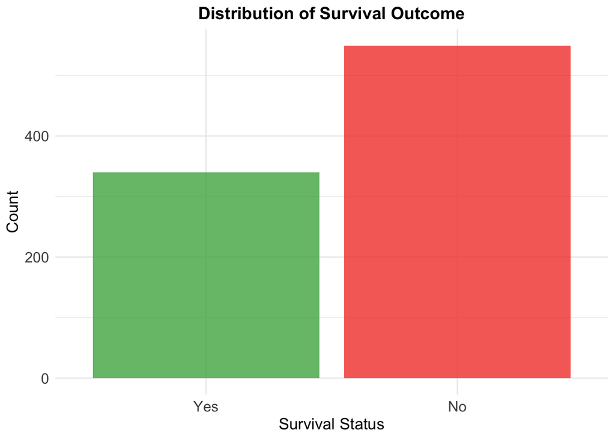

```r
# Bar plot of the 'survived' variable
ggplot(titanic, aes(x = survived)) +
  geom_bar(fill = c("#4CAF50", "#F44336"), alpha = 0.8) +
  labs(
    title = "Distribution of Survival Outcome",
    x = "Survival Status",
    y = "Count"
  ) +
  theme_minimal() +
  theme(
    plot.title = element_text(hjust = 0.5, size = 14, face = "bold"),
    axis.text = element_text(size = 12),
    axis.title = element_text(size = 13)
  )
```

### Survival by Gender

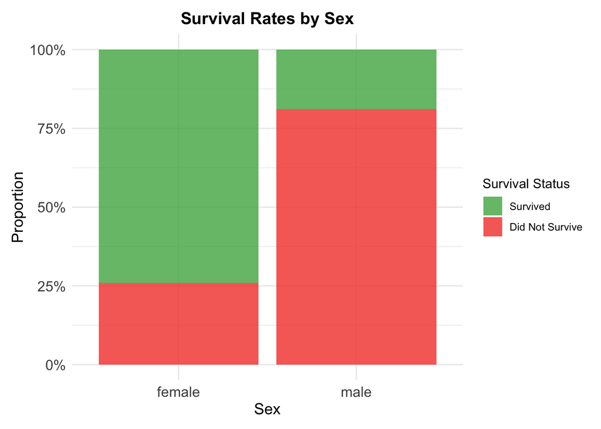

```r
# Bar plot of survival by sex
ggplot(titanic, aes(x = sex, fill = survived)) +
  geom_bar(position = "fill", alpha = 0.8) +
  scale_y_continuous(labels = scales::percent) +
  scale_fill_manual(values = c("#4CAF50", "#F44336"),
                    labels = c("Survived", "Did Not Survive")) +
  labs(
    title = "Survival Rates by Sex",
    x = "Sex",
    y = "Proportion",
    fill = "Survival Status"
  ) +
  theme_minimal() +
  theme(
    plot.title = element_text(hjust = 0.5, size = 14, face = "bold"),
    axis.text = element_text(size = 12),
    axis.title = element_text(size = 13),
    plot.margin = margin(t = 10, r = 10, b = 10, l = 10)
  )
```

The proportion of survivors shows vastly more females survived than males. The higher proportion of females compared to males aligns with historical principles of “women and children first,” which was applied during the Titanic disaster’s evacuation.

### Survival by Age

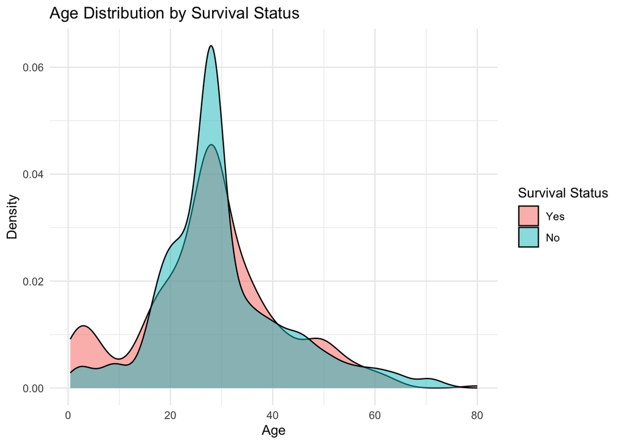

```r
ggplot(titanic, aes(x = age, fill = survived)) +
  geom_density(alpha = 0.5) +
  labs(
    title = "Age Distribution by Survival Status",
    x = "Age",
    y = "Density",
    fill = "Survival Status"
  ) +
  theme_minimal()
```

Our distributions follow a normal bell shape with peaks in both distributions maximizing at about 20-40 years. Most passengers fall in this range, representing adults. On the left, and notably survived, a spike in number of younger passengers (children). This follows our previous conclusion that women and children primarily survived. Our distributions are skewed to the right, representing a few passengers aged 50+. Most passengers that didn’t survive were young adults and primarily male.

### Survival by Family

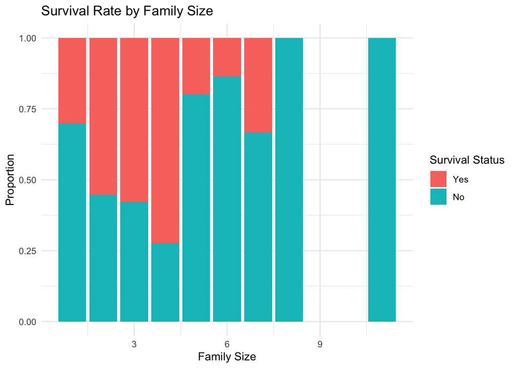

```r
titanic <- titanic %>%
  mutate(family_size = sib_sp + parch + 1)

ggplot(titanic, aes(x = family_size, fill = survived)) +
  geom_bar(position = "fill") +
  labs(
    title = "Survival Rate by Family Size",
    x = "Family Size",
    y = "Proportion",
    fill = "Survival Status"
  ) +
  theme_minimal()
```

### Survival by Class

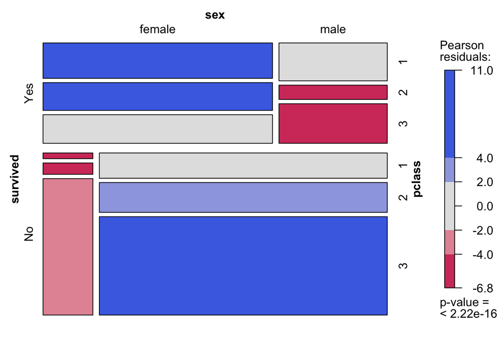

```r
mosaic(~ survived + sex + pclass, data = titanic, shade = TRUE)
```

Firstly let’s look at the colors: pink indicates a negative relationship between gender and survival, and blue is positively correlated (gray is uncorrelated). Again we observe positive survival correlations (blue) for females and negative (pink) for males.

Under the non-survived grouping, we can see the disproportionate amount of 3rd class male passengers triples the amount of 1st and 2nd class non-survivors. The same applies for females in the 3rd class, and the proportion of non-surviving 1st and 2nd class females is a sliver in comparison. This shows the wealth disparity for passengers in poorer cabins of the Titanic. Evacuation for 3rd class proved impossible due to a combination of physical separation, and lack of access to lifeboats.

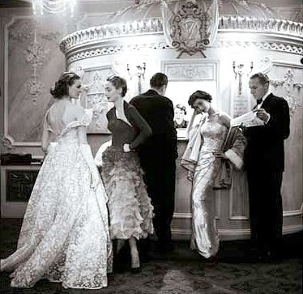

[figure not shown]

# Model Set Up

### Splitting the Data

Before we do any model building, we have to perform a training / testing split on our data. I decided to go with 70/30 for this data so the testing data set will still have a significant amount of observations, but our model has more to train on and learn. The reason we do this is because we want to avoid over-fitting, so the testing set is reserved as this answer key. We also set a random seed to ensure the training / testing split is the same set every time we go back and work on the following code. We stratify on our response variable `survived`, to ensure that the `survived` variable is used to maintain the proportion of survivors and non-survivors in both the training and testing sets.

```r
#ensure recipe gets correct data
titanic <- titanic %>%
  mutate(
    survived = factor(survived, levels = c("Yes", "No")),
    pclass = factor(pclass)
  )

set.seed(3435)
titanic_split <- titanic %>%
  initial_split(strata = survived, prop = 0.7)
titanic_train <- training(titanic_split)
titanic_test <- testing(titanic_split)
dim(titanic_train)
```

```
## [1] 621  13
```

```r
dim(titanic_test)
```

```
## [1] 268  13
```

```r
nrow(titanic_train)/nrow(titanic)
```

```
## [1] 0.6985377
```

```r
nrow(titanic_test)/nrow(titanic)
```

```
## [1] 0.3014623
```

### Recipe Building

Because we are going to use the same predictors, model conditions, and response variable, we create one central recipe for all the models we will build. By using a recipe, you are ensuring that your data pre-processing is robust, consistent, and easily reusable across multiple models. This will make it easy to compare fitted models and choose the best one.

```r
titanic_recipe <- recipe(survived ~ pclass + sex + age +
                           sib_sp + parch + fare, titanic_train) %>%
  step_impute_median(age) %>%
  step_dummy(all_nominal(), -survived) %>%
  step_zv(all_predictors())  # Removing zero variance predictors
```

### K-Fold Cross Validation

We are going to use stratified cross validation to help with the issue of imbalanced data, and we are of course going to stratify on our response variable, `survived`. When fitting a model, you want to ensure that your evaluation metrics are robust. Instead of just relying on a single train/test split, cross-validation divides the training data into several folds and trains the model multiple times, each time using a different fold for testing and the remaining folds for training. This process gives a better estimate of model performance and generalization. We use k-fold cross validation rather than simply fitting and testing models on the entire training set because cross validation provides a better estimate of the testing accuracy. It is better to take the mean accuracy from several samples instead of just one accuracy from one sample because, as n increases, we reduce variation.

```r
# 10-fold cross-validation
cv_splits <- vfold_cv(titanic_train, v = 10, strata = "survived")

# Check the distribution of the outcome variable in each fold
cv_splits$splits[[1]] %>%
  analysis() %>%
  count(survived)
```

| survived | n |
| --- | --- |
| Yes | 213 |
| No | 345 |

## Model Building

**How do we fit on a model?**

1. Set up the model by specifying what type of model, setting its engine, and setting its mode (which was always classification)
2. Set up the workflow, add the new model, and add the established recipe.

Skip steps 3-5 for Logistic Regression (few hyperparameters to tune).

3. Set up the tuning grid with the parameters that we want tuned, and how many different levels of tuning
4. Tune the model and specify the workflow, k-fold cross validation folds, and the tuning grid for our chosen parameters to tune
5. Select the most accurate model from all of the tuning, finalize the workflow with those tuning parameters
6. Fit that model with our workflow to the training data set

Now that we have the steps, let’s fit our prepared training sets on 4 different models. Picking our models depends on classification vs. regression as well as linearity and normality. Let’s take a look:

**1. Logistic Regression:**

It’s a good baseline model for classification tasks. It’s interpretable and provides clear insights into the relationships between predictors and the outcome. Works well if the relationships between features and the target are linear.

**2. Random Forest**

It’s a powerful, non-linear model that handles both numerical and categorical features well. Automatically captures interactions and non-linear relationships. Robust to overfitting and provides feature importance scores. A potential drawback is computation time, which works in our favor.

**3. Lasso (Logistic Regression with L1 Penalty)**

Performs feature selection by shrinking some coefficients to zero. Useful for datasets with many predictors or collinearity issues. **When to skip**: If your dataset has relatively few features (as in Titanic) or no strong collinearity.

**4. K-Nearest Neighbor (k-NN)**

Intuitive and effective for small to medium-sized datasets. Makes no assumptions about the data distribution. A potential drawback is computation expense, which works in our favor.

**After our models are fit, how will we pick the best model?**

#### Performance Metric: ROC

I decided to set my metric of performance as **roc_auc**, because that is what shows the most significant level of efficiency in a binary classification model where the data is not perfectly balanced. This essentially calculates the area under the curve for the receiver operating characteristic (ROC) curve, which highlights the trade-off between sensibility and sensitivity.

```r
roc_auc_table <- data.frame(
  `ROC AUC Range` = c("0.5", "0.6–0.7", "0.7–0.8", "0.8–0.9", "0.9–1.0"),
  Performance = c("No discrimination", "Poor discrimination", "Acceptable discrimination", "Excellent discrimination", "Outstanding discrimination"))
roc_auc_table
```

| ROC.AUC.Range | Performance |
| --- | --- |
| 0.5 | No discrimination |
| 0.6–0.7 | Poor discrimination |
| 0.7–0.8 | Acceptable discrimination |
| 0.8–0.9 | Excellent discrimination |
| 0.9–1.0 | Outstanding discrimination |

### 1. Logistical Regression Model

Logistic regression starts with a linear model. Just like linear regression, we use a linear equation to predict a continuous outcome. However, the prediction from this model is not constrained between 0 and 1, which is necessary for a probability. This is where the logistic (sigmoid) function comes in. This transforms the output of the linear equation into a probability between 0 and 1. Then the model coefficients are learned by maximizing the likelihood of the data (MLE).

Let’s put it to work!

```r
log_reg_model <- logistic_reg(mode = "classification") %>%
  set_engine("glm")

log_reg_workflow <- workflow() %>%
  add_model(log_reg_model) %>%
  add_recipe(titanic_recipe)

log_reg_fit <- fit(log_reg_workflow, data = titanic_train)

log_reg_preds <- predict(log_reg_fit, titanic_test, type = "prob") %>%
  bind_cols(predict(log_reg_fit, titanic_test)) %>%
  bind_cols(titanic_test)

# Compute ROC AUC Metric
roc_auc_log <- roc_auc(log_reg_preds, truth = survived, .pred_Yes)
roc_auc_log
```

| .metric | .estimator | .estimate |
| --- | --- | --- |
| roc_auc | binary | 0.8746984 |

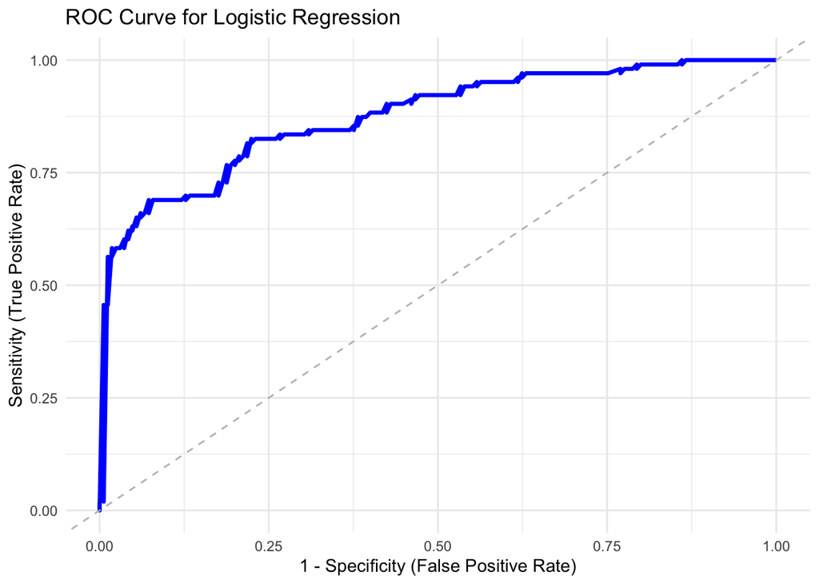

```r
# ROC Curve Plot
roc_curve_data <- roc_curve(log_reg_preds, truth = survived, .pred_Yes)

ggplot(roc_curve_data, aes(x = 1 - specificity, y = sensitivity)) +
  geom_line(color = "blue", linewidth = 1.2) +
  geom_abline(linetype = "dashed", color = "gray") +
  labs(
    title = "ROC Curve for Logistic Regression",
    x = "1 - Specificity (False Positive Rate)",
    y = "Sensitivity (True Positive Rate)"
  ) +
  theme_minimal()
```

Our Logistical Regression model ROC value is excellent discrimination, in other words our model can reliably distinguish between survivors and non-survivors!

For a simple data set with clear separability (Titanic has strong survival predictors like sex and class), an AUC > 0.85 is expected.

### 2. Random Forest Model

A random forest model is a supervised ensemble learning technique that consists of numerous decision trees. Decision tree models tend to struggle with over-fitting the training data, which is overcome in a random forest by averaging the prediction results of each decision tree and determining a final output. The random forest algorithm stacks multiple classifiers together to improve its overall performance!

```r
rf_model <- rand_forest(mode = "classification", mtry = 3, trees = 500) %>%
  set_engine("randomForest")

# Set up the workflow with the recipe and model
rf_workflow <- workflow() %>%
  add_model(rf_model) %>%
  add_recipe(titanic_recipe)

# Fit the model to the training data
rf_fit <- fit(rf_workflow, data = titanic_train)

# Make predictions on the test data
rf_preds <- predict(rf_fit, titanic_test, type = "prob") %>%
  bind_cols(predict(rf_fit, titanic_test)) %>%
  bind_cols(titanic_test)

# Compute ROC AUC Metric
roc_auc_rf <- roc_auc(rf_preds, truth = survived, .pred_Yes)
roc_auc_rf
```

| .metric | .estimator | .estimate |
| --- | --- | --- |
| roc_auc | binary | 0.89391 |

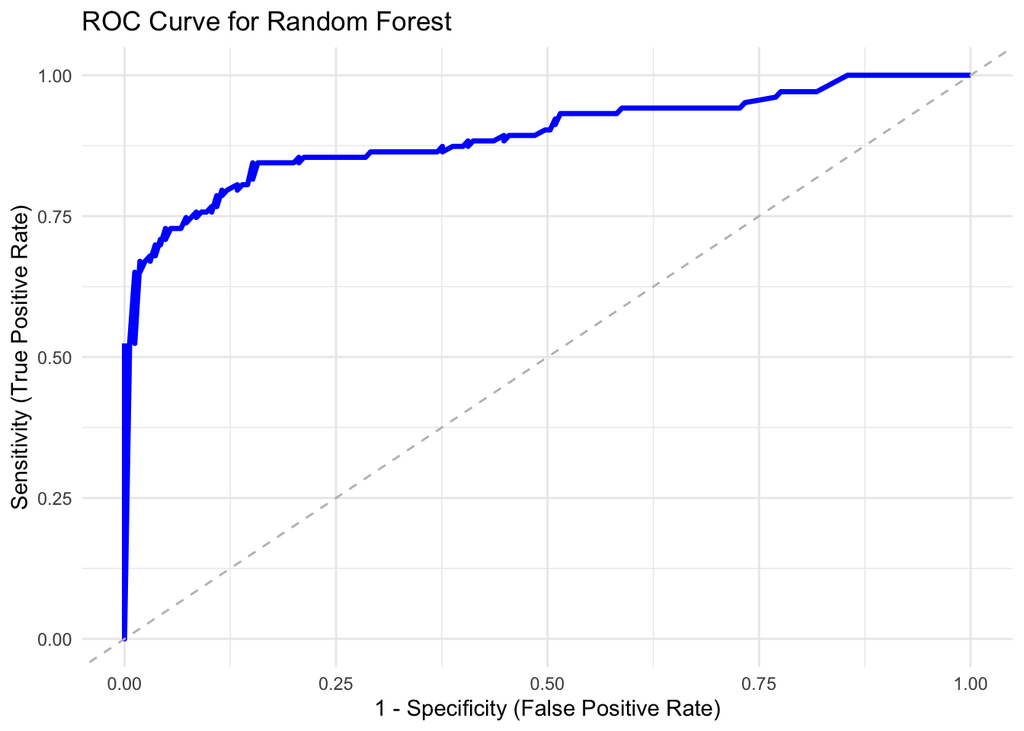

```r
# ROC Curve Plot
roc_curve_data <- roc_curve(rf_preds, truth = survived, .pred_Yes)

ggplot(roc_curve_data, aes(x = 1 - specificity, y = sensitivity)) +
  geom_line(color = "blue", linewidth = 1.2) +
  geom_abline(linetype = "dashed", color = "gray") +
  labs(
    title = "ROC Curve for Random Forest",
    x = "1 - Specificity (False Positive Rate)",
    y = "Sensitivity (True Positive Rate)"
  ) +
  theme_minimal()
```

While the model is performing well with an AUC of 0.89, there’s always room for improvement. Let’s try model tuning to potentially enhance performance further. Random Forests in particular can often benefit from tuning hyper-parameters like: `min_n`, `mtry`, and `trees`

**Tuning Random Forest Model Parameters:**

- `mtry` which represents the amount of predictors that will be sampled randomly during the creation of the models.
- `trees` which represents the amount of trees present in the random forest model.
- `min_n` which represents the minimum amount of data values required to be in a tree node in order for it to be split further down the tree.

```r
# Define the random forest model with tunable parameters
rf_model <- rand_forest(
  mode = "classification",
  mtry = tune(),    # mtry is a tuning parameter
  trees = tune(),   # trees is a tuning parameter
  min_n = tune()    # min_n is a tuning parameter
) %>%
  set_engine("randomForest") %>%
  set_mode("classification")

# workflow with variable tuning
rf_forest_workflow <- workflow() %>%
  add_model(rf_model) %>%
  add_recipe(titanic_recipe)

rf_grid <- grid_regular(
  mtry(range = c(2, 5)),   # Fewer values for mtry
  trees(range = c(100, 500)), # Fewer trees
  min_n(range = c(2, 5)),  # Fewer values for min_n
  levels = 3                # Reduce levels
)

# Run the tuning with cross-validation
rf_tune <- tune_grid(
  rf_forest_workflow,
  resamples = cv_splits,  # Using cross-validation splits
  grid = rf_grid
)

# View the best tuning results
rf_tune_results <- rf_tune %>%
  collect_metrics()

# Check for the best parameters and AUC
rf_tune_results %>%
  filter(.metric == "roc_auc") %>%
  arrange(desc(mean))
```

| mtry | trees | min_n | .metric | .estimator | mean | n | std_err | .config |
| --- | --- | --- | --- | --- | --- | --- | --- | --- |
| 2 | 100 | 5 | roc_auc | binary | 0.8637954 | 10 | 0.01578707 | Preprocessor1_Model19 |
| 2 | 300 | 2 | roc_auc | binary | 0.8624722 | 10 | 0.01525174 | Preprocessor1_Model04 |
| 2 | 500 | 5 | roc_auc | binary | 0.8621541 | 10 | 0.01462868 | Preprocessor1_Model25 |
| 2 | 500 | 3 | roc_auc | binary | 0.8621131 | 10 | 0.01533117 | Preprocessor1_Model16 |
| 2 | 500 | 2 | roc_auc | binary | 0.8614437 | 10 | 0.01519915 | Preprocessor1_Model07 |
| 2 | 100 | 3 | roc_auc | binary | 0.8607668 | 10 | 0.01374513 | Preprocessor1_Model10 |
| 3 | 100 | 5 | roc_auc | binary | 0.8605656 | 10 | 0.01323464 | Preprocessor1_Model20 |
| 2 | 100 | 2 | roc_auc | binary | 0.8596101 | 10 | 0.01458885 | Preprocessor1_Model01 |
| 2 | 300 | 5 | roc_auc | binary | 0.8587189 | 10 | 0.01411140 | Preprocessor1_Model22 |
| 2 | 300 | 3 | roc_auc | binary | 0.8578427 | 10 | 0.01501434 | Preprocessor1_Model13 |

[output cut: 17 more lines]

```r
best_rf_result <- rf_tune_results %>%
  filter(.metric == "roc_auc") %>%  # Filter only for ROC AUC metric
  slice_max(mean, n = 1)           # Select the row with the highest mean value

print(best_rf_result)
```

```
## # A tibble: 1 × 9
##    mtry trees min_n .metric .estimator  mean     n std_err .config
##   <int> <int> <int> <chr>   <chr>      <dbl> <int>   <dbl> <chr>
## 1     2   100     5 roc_auc binary     0.864    10  0.0158 Preprocessor1_Model19
```

**However, the model has better ROC AUC value 0.89 before tuning parameters, so we will keep the original Random Forest model.**

### 3. Lasso (Logistic Regression with L1 Penalty) Model

Lasso regression, short for **Least Absolute Shrinkage and Selection Operator**, is a type of regression analysis used for both prediction and feature selection. It’s especially useful when you have many features and suspect that some are irrelevant or redundant. Lasso works by adding a penalty term to the ordinary least squares (OLS) loss function that encourages simpler models with fewer predictors. Since our data is relatively small this model may not fit better than others. Let’s try it out!

```r
lasso_model <- logistic_reg(
  mode = "classification",
  penalty = tune(),  # Tuning parameter
  mixture = 1        # Full Lasso (mixture = 1 corresponds to Lasso)
) %>%
  set_engine("glmnet")

# Set up the workflow with the recipe and model
lasso_workflow <- workflow() %>%
  add_model(lasso_model) %>%
  add_recipe(titanic_recipe)

# Define a grid for the penalty parameter
lasso_grid <- grid_regular(
  penalty(range = c(-5, 0)),  # Log-scale range for the penalty (lambda)
  levels = 50                # Number of levels in the grid
)

# Tune the Lasso model
lasso_tune <- tune_grid(
  lasso_workflow,
  resamples = cv_splits,  # Use cross-validation splits
  grid = lasso_grid,
  metrics = metric_set(roc_auc)  # Use ROC AUC as the evaluation metric
)

lasso_results <- lasso_tune %>%
  collect_metrics()

lasso_results %>%
  filter(.metric == "roc_auc") %>%
  arrange(desc(mean))  # Sort by best ROC AUC
```

| penalty | .metric | .estimator | mean | n | std_err | .config |
| --- | --- | --- | --- | --- | --- | --- |
| 1.000000e-05 | roc_auc | binary | 0.8441689 | 10 | 0.01286314 | Preprocessor1_Model01 |
| 1.264855e-05 | roc_auc | binary | 0.8441689 | 10 | 0.01286314 | Preprocessor1_Model02 |
| 1.599859e-05 | roc_auc | binary | 0.8441689 | 10 | 0.01286314 | Preprocessor1_Model03 |
| 2.023590e-05 | roc_auc | binary | 0.8441689 | 10 | 0.01286314 | Preprocessor1_Model04 |
| 2.559548e-05 | roc_auc | binary | 0.8441689 | 10 | 0.01286314 | Preprocessor1_Model05 |
| 3.237458e-05 | roc_auc | binary | 0.8441689 | 10 | 0.01286314 | Preprocessor1_Model06 |
| 4.094915e-05 | roc_auc | binary | 0.8441689 | 10 | 0.01286314 | Preprocessor1_Model07 |
| 5.179475e-05 | roc_auc | binary | 0.8441689 | 10 | 0.01286314 | Preprocessor1_Model08 |
| 6.551286e-05 | roc_auc | binary | 0.8441689 | 10 | 0.01286314 | Preprocessor1_Model09 |
| 8.286428e-05 | roc_auc | binary | 0.8441689 | 10 | 0.01286314 | Preprocessor1_Model10 |

[output cut: 40 more lines]

```r
# find best penalty value
best_lasso <- lasso_tune %>%
  select_best(metric = "roc_auc")
# Finalize the workflow with the best parameters
final_lasso_workflow <- finalize_workflow(lasso_workflow, best_lasso)

# Fit the final model to the training data
final_lasso_fit <- fit(final_lasso_workflow, data = titanic_train)

# Make predictions on the test data
lasso_preds <- predict(final_lasso_fit, titanic_test, type = "prob") %>%
  bind_cols(predict(final_lasso_fit, titanic_test)) %>%
  bind_cols(titanic_test)

# Compute the ROC AUC
roc_auc_lasso <- roc_auc(lasso_preds, truth = survived, .pred_Yes)
roc_auc_lasso
```

| .metric | .estimator | .estimate |
| --- | --- | --- |
| roc_auc | binary | 0.8756987 |

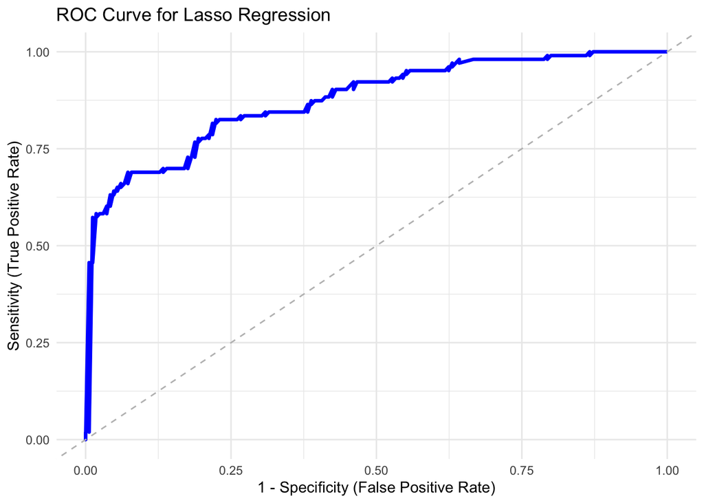

```r
# Plot the ROC Curve
roc_curve_data <- roc_curve(lasso_preds, truth = survived, .pred_Yes)

ggplot(roc_curve_data, aes(x = 1 - specificity, y = sensitivity)) +
  geom_line(color = "blue", linewidth = 1.2) +
  geom_abline(linetype = "dashed", color = "gray") +
  labs(
    title = "ROC Curve for Lasso Regression",
    x = "1 - Specificity (False Positive Rate)",
    y = "Sensitivity (True Positive Rate)"
  ) +
  theme_minimal()
```

Our model did okay with an ROC AUC of 8.75: A value closer to 1 is excellent, and values above 0.85 typically represent a strong model, especially for imbalanced datasets. This is not our best performing metric as of yet, even with parameter tuning. Let’s move on to K-NN modeling.

### 4. K-Nearest Neighbor (k-NN) Model

The k-Nearest Neighbors algorithm is a non-parametric, instance-based learning method used for classification and regression tasks. It predicts outcomes based on the similarity of data points in the feature space. k-NN identifies the `k` closest data points (neighbors) to a target observation in the training data set (for future prediction). Think of grouping classifiers with clusters of similar types based on distance measurements, such as the *Euclidean distance*. We can use K-Nearest Neighbor for smaller data sets where computational cost is manageable as well.

```r
knn_model <- nearest_neighbor(
  neighbors = tune(), # Tuning parameter: number of neighbors (k)
  weight_func = "rectangular",
  dist_power = 2 # Euclidean distance
) %>%
  set_engine("kknn") %>%
  set_mode("classification")

knn_grid <- grid_regular(
  neighbors(range = c(1, 30)), # Range of k values to tune
  levels = 10 # Number of grid levels
)

knn_workflow <- workflow() %>%
  add_model(knn_model) %>%
  add_recipe(titanic_recipe) # Use the existing recipe
```

```r
knn_tune <- tune_grid(
  knn_workflow,
  resamples = cv_splits, # previous 10-fold cross-validation
  grid = knn_grid
)

# best tuning results
knn_tune_results <- knn_tune %>%
  collect_metrics()

# Select the best k based on ROC AUC
best_knn <- select_best(knn_tune, metric = "roc_auc")
print(best_knn)
```

```
## # A tibble: 1 × 2
##   neighbors .config
##       <int> <chr>
## 1        23 Preprocessor1_Model08
```

```r
# Finalize the workflow with the best k value
final_knn <- finalize_workflow(knn_workflow, best_knn)

# Fit the final model to the training data
knn_fit <- fit(final_knn, data = titanic_train)
```

```r
# Make predictions on the test set
knn_preds <- predict(knn_fit, titanic_test, type = "prob") %>%
  bind_cols(predict(knn_fit, titanic_test)) %>%
  bind_cols(titanic_test)

# Compute ROC AUC
roc_auc_knn <- roc_auc(knn_preds, truth = survived, .pred_Yes)
print(roc_auc_knn)
```

```
## # A tibble: 1 × 3
##   .metric .estimator .estimate
##   <chr>   <chr>          <dbl>
## 1 roc_auc binary         0.867
```

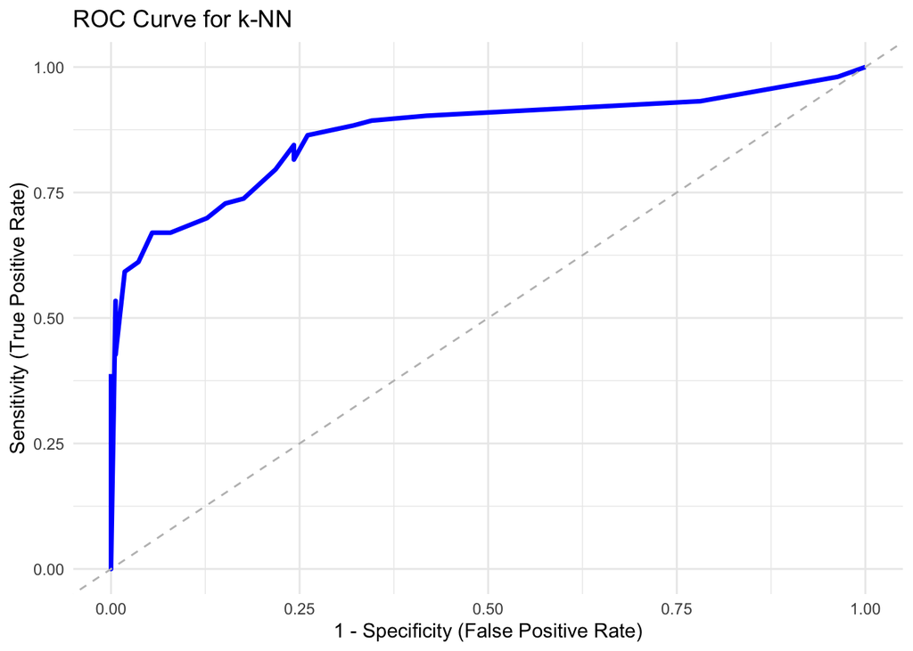

```r
# ROC Curve
roc_curve_data <- roc_curve(knn_preds, truth = survived, .pred_Yes)

ggplot(roc_curve_data, aes(x = 1 - specificity, y = sensitivity)) +
  geom_line(color = "blue", linewidth = 1.2) +
  geom_abline(linetype = "dashed", color = "gray") +
  labs(
    title = "ROC Curve for k-NN",
    x = "1 - Specificity (False Positive Rate)",
    y = "Sensitivity (True Positive Rate)"
  ) +
  theme_minimal()
```

Our value of 0.867 is a good range, but let’s try to improve it!

**Tuning Neighbors**

Our parameter `neighbors` is the most important tuning parameter for k-NN. It defines the number of nearest neighbors to be considered when making a prediction for a new data point.

Effect:

- If k is small (e.g., 1 or 3), the model may be sensitive to noise, leading to overfitting.
- If k is large, the model may become too general and underfit.
- A good k helps balance the trade-off between underfitting and overfitting.

We will now find our best K value with a tuning grid:

```r
# Create a refined grid for tuning k
knn_grid_refined <- grid_regular(
  neighbors(range = c(3, 15)), # Focused range around promising values
  levels = 13 # Test k = 3 through k = 15 with step = 1
)

# Run the refined tuning with cross-validation
knn_tune_refined <- tune_grid(
  knn_workflow,
  resamples = cv_splits, # Existing 10-fold cross-validation splits
  grid = knn_grid_refined
)

# Collect refined tuning results
knn_tune_refined_results <- knn_tune_refined %>%
  collect_metrics()

# Select the best k based on ROC AUC
best_knn_refined <- select_best(knn_tune_refined, metric = "roc_auc")

# Print the best parameters
print(best_knn_refined)
```

```
## # A tibble: 1 × 2
##   neighbors .config
##       <int> <chr>
## 1        11 Preprocessor1_Model09
```

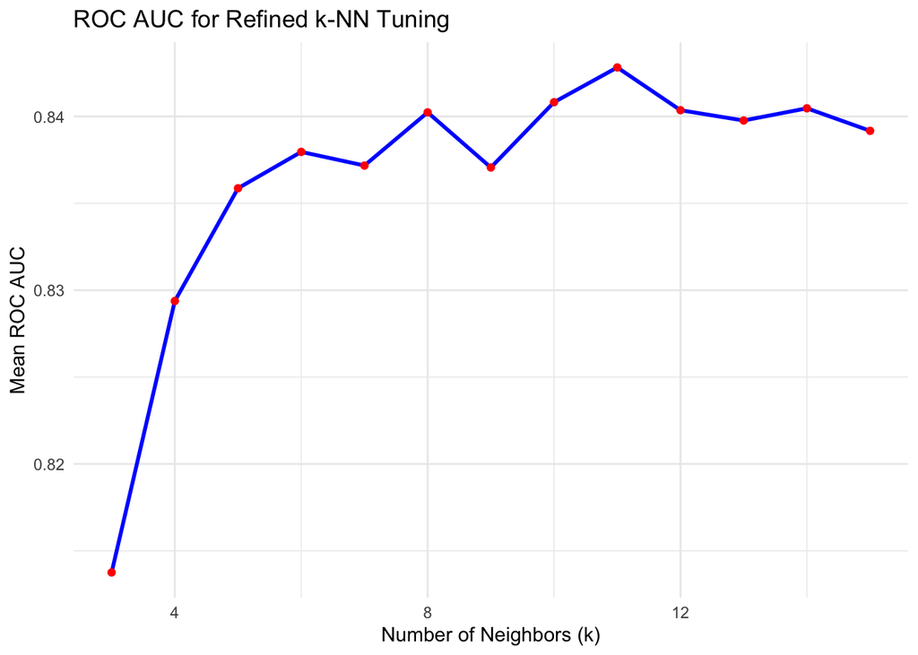

```r
# Plot the ROC AUC results for visualization
knn_tune_refined_results %>%
  filter(.metric == "roc_auc") %>%
  ggplot(aes(x = neighbors, y = mean)) +
  geom_line(color = "blue", linewidth = 1) +
  geom_point(color = "red") +
  labs(
    title = "ROC AUC for Refined k-NN Tuning",
    x = "Number of Neighbors (k)",
    y = "Mean ROC AUC"
  ) +
  theme_minimal()
```

Our best tuning parameter for `neighbor` is **11**! Let’s run our model again with this new information.

```r
# Use the best k from the refined tuning process: 11!
best_knn_refined_k <- best_knn_refined$neighbors

# Update the k-NN model with the best k value
knn_final_model <- nearest_neighbor(
  neighbors = best_knn_refined_k,
  weight_func = "rectangular",
  dist_power = 2
) %>%
  set_engine("kknn") %>%
  set_mode("classification")

# Finalize the workflow with the chosen model and recipe
final_knn_workflow <- workflow() %>%
  add_model(knn_final_model) %>%
  add_recipe(titanic_recipe)

# Fit the final model to the full training data
final_knn_fit <- fit(final_knn_workflow, data = titanic_train)

# Make predictions on the test data
final_knn_preds <- predict(final_knn_fit, titanic_test, type = "prob") %>%
  bind_cols(predict(final_knn_fit, titanic_test)) %>%
  bind_cols(titanic_test)

# Compute ROC AUC Metric
roc_auc_knn <- roc_auc(final_knn_preds, truth = survived, .pred_Yes)
print(roc_auc_knn)
```

```
## # A tibble: 1 × 3
##   .metric .estimator .estimate
##   <chr>   <chr>          <dbl>
## 1 roc_auc binary         0.876
```

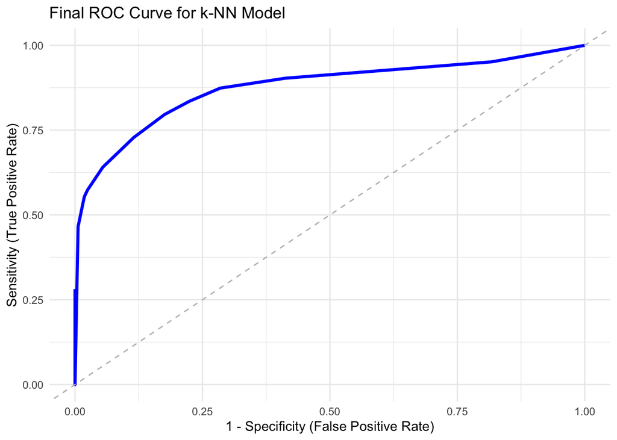

```r
# ROC Curve Plot
final_roc_curve_data <- roc_curve(final_knn_preds, truth = survived, .pred_Yes)

ggplot(final_roc_curve_data, aes(x = 1 - specificity, y = sensitivity)) +
  geom_line(color = "blue", linewidth = 1.2) +
  geom_abline(linetype = "dashed", color = "gray") +
  labs(
    title = "Final ROC Curve for k-NN Model",
    x = "1 - Specificity (False Positive Rate)",
    y = "Sensitivity (True Positive Rate)"
  ) +
  theme_minimal()
```

Our model has improved a bit with `neighbor` parametric tuning. An ROC AUC of 0.876: Excellent discrimination.

We have 4 models with excellent ROC AUC values, let’s compare these and finalize the best predictive powered engine!

# Model Selection

It’s finally time to compare the results of all of our models and see which ones performed the best! Let’s make a tibble with the ROC AUC values from each model.

```r
final_compare_tibble <- tibble(Model = c("Logistic Regression", "Random Forest", "Lasso Regression", "K Nearest Neighbors"), ROC_AUC = c(roc_auc_log$.estimate, roc_auc_rf$.estimate, roc_auc_lasso$.estimate, roc_auc_knn$.estimate))

# Arranging by lowest RMSE
final_compare_tibble <- final_compare_tibble %>%
  arrange(desc(ROC_AUC))

final_compare_tibble
```

| Model | ROC_AUC |
| --- | --- |
| Random Forest | 0.8939100 |
| K Nearest Neighbors | 0.8761989 |
| Lasso Regression | 0.8756987 |
| Logistic Regression | 0.8746984 |

Logistic regression likely underperformed because it is too simple to capture the complex relationships in the Titanic dataset, especially when compared to Random Forest, which is more flexible and able to model non-linear interactions between features.

KNN worked well due to its ability to capture local patterns and non-linear relationships without making assumptions about the data.

Lasso was effective because of its ability to perform feature selection and avoid overfitting, especially if there were irrelevant or highly correlated features in the dataset.

- Both models did well, but **Random Forest** outperformed them because of its ensemble nature, ability to model non-linearities, and automatic handling of feature interactions without requiring explicit tuning of hyperparameters.

**Let’s visualize the model performances.**

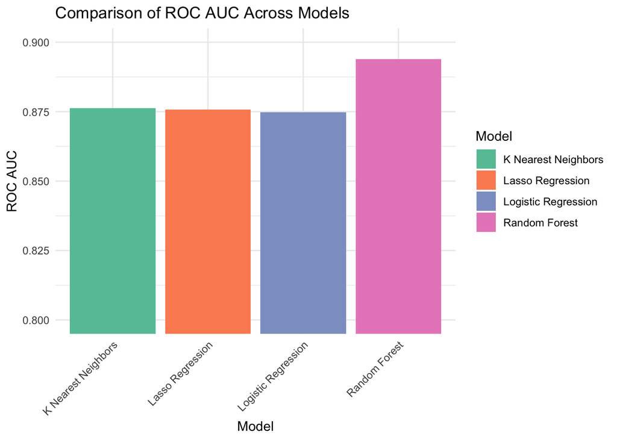

```r
# Histogram of ROC AUC values
ggplot(final_compare_tibble, aes(x = Model, y = ROC_AUC, fill = Model)) +
  geom_col() +
  labs(
    title = "Comparison of ROC AUC Across Models",
    x = "Model",
    y = "ROC AUC"
  ) +
  theme_minimal() +
  scale_fill_brewer(palette = "Set2") +
  theme(
    axis.text.x = element_text(angle = 45, hjust = 1)
  ) +
  coord_cartesian(ylim = c(0.8, 0.9))  # Adjust y-axis range to zoom in
```

This is probably due to the dataset following an interesting relationship whereas prominent behavioral patterns dictated the randomness of our data. Since all the women and children on the Titanic were first priority, the data is biased in predictors and survivors.

- The k-NN model performed well with a **ROC AUC of 0.876**, suggesting that the relationships between data points (neighbors) in feature space provide meaningful insights. However, it is slightly less robust than Random Forest, likely because it lacks a mechanism for learning feature importance.
- Both Lasso Regression and Logistic Regression have similar **ROC AUC values (0.876 and 0.875**, respectively). This indicates that linear models with regularization (Lasso) or standard generalized linear models (Logistic Regression) can capture important patterns but may be limited in capturing non-linear relationships in the dataset.

## Congratulations to Random Forest!

We will work with one of the random forest models because that was the best performer. I am curious which random forest outperformed the rest! We have already selected the best of our models, so there is no need to finalize the workflows or anything like that. Now, all there is to do is analyze the best random forest as our champion model, and then fit it to our testing data to analyze its true performance.

```r
# Prepare the recipe and bake it on the test data
prepped_recipe <- prep(titanic_recipe, training = titanic_train)
processed_test <- bake(prepped_recipe, new_data = titanic_test)

# Extract the random forest model (fit)
rf_object <- extract_fit_engine(rf_fit)

# Make predictions using all trees in the random forest
individual_tree_preds <- predict(rf_object, processed_test, predict.all = TRUE)

# Initialize a vector to store AUC values for each tree
tree_roc_values <- numeric(ncol(individual_tree_preds$individual))

# Loop through each tree's predictions
for (i in 1:ncol(individual_tree_preds$individual)) {
  # Get predictions for the i-th tree and convert "Yes"/"No" to numeric (1/0)
  current_preds <- as.numeric(individual_tree_preds$individual[, i] == "Yes")

  # Calculate ROC AUC for the current tree's predictions, suppressing warnings and messages
  roc <- suppressMessages(suppressWarnings(roc(processed_test$survived, current_preds)))
  tree_roc_values[i] <- auc(roc)
}

# Print the results of AUC values for all trees
#tree_roc_values

# Identify the index of the best-performing tree
best_tree_index <- which.max(tree_roc_values)
best_auc <- tree_roc_values[best_tree_index]

# Create a tibble to store the results for the best tree
best_tree_result <- tibble(Tree = best_tree_index, ROC_AUC = best_auc)

# Print the result
print(best_tree_result)
```

```
## # A tibble: 1 × 2
##    Tree ROC_AUC
##   <int>   <dbl>
## 1    85   0.846
```

### Congratulations Random Forest Tree #85!

Our most impressive tree of the Random Forest Model is #85, with an AUC of `0.846` .

The AUC of our best-performing individual tree being lower than the ensemble (0.846 vs. 0.89) simply indicates that this particular tree doesn’t capture all the complexities of the data as well as the combined model does. However, the random forest as a whole benefits from the predictions of all trees, including the one with lower AUC.

**Let’s check on our testing data!**

```r
# Make predictions on the test set using the fitted model
rf_preds <- predict(rf_fit, titanic_test, type = "prob") %>%
  bind_cols(predict(rf_fit, titanic_test)) %>%
  bind_cols(titanic_test) # Adding the original test data to the predictions

# View the first few rows of the predictions
head(rf_preds)
```

| .pred_Yes | .pred_No | .pred_class | passenger_id | survived | pclass | name | sex | age | sib_sp | parch | ticket | fare | cabin | embarked | family_size |
| --- | --- | --- | --- | --- | --- | --- | --- | --- | --- | --- | --- | --- | --- | --- | --- |
| 0.972 | 0.028 | Yes | 2 | Yes | 1 | Cumings, Mrs. John Bradley (Florence Briggs Thayer) | female | 38 | 1 | 0 | PC 17599 | 71.2833 | C85 | C | 2 |
| 0.994 | 0.006 | Yes | 4 | Yes | 1 | Futrelle, Mrs. Jacques Heath (Lily May Peel) | female | 35 | 1 | 0 | 113803 | 53.1000 | C123 | S | 2 |
| 0.010 | 0.990 | No | 6 | No | 3 | Moran, Mr. James | male | 28 | 0 | 0 | 330877 | 8.4583 | B96 B98 | Q | 1 |
| 0.002 | 0.998 | No | 13 | No | 3 | Saundercock, Mr. William Henry | male | 20 | 0 | 0 | A/5. 2151 | 8.0500 | B96 B98 | S | 1 |
| 0.080 | 0.920 | No | 21 | No | 2 | Fynney, Mr. Joseph J | male | 35 | 0 | 0 | 239865 | 26.0000 | B96 B98 | S | 1 |
| 0.052 | 0.948 | No | 26 | Yes | 3 | Asplund, Mrs. Carl Oscar (Selma Augusta Emilia Johansson) | female | 38 | 1 | 5 | 347077 | 31.3875 | B96 B98 | S | 7 |

```r
# Check the distribution of predicted probabilities for 'Yes'
summary(rf_preds$.pred_Yes)
```

```
##    Min. 1st Qu.  Median    Mean 3rd Qu.    Max.
##  0.0000  0.0235  0.1590  0.3619  0.7585  1.0000
```

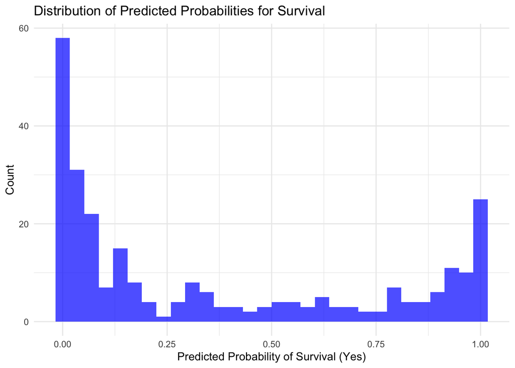

```r
# Plot the predicted probabilities for survival
ggplot(rf_preds, aes(x = .pred_Yes)) +
  geom_histogram(bins = 30, fill = "blue", alpha = 0.7) +
  labs(title = "Distribution of Predicted Probabilities for Survival",
       x = "Predicted Probability of Survival (Yes)",
       y = "Count") +
  theme_minimal()
```

The histogram we created shows the distribution of predicted probabilities for survival. Given the skewed nature of the predicted probabilities (more concentrated towards 0), it’s likely that our model struggles to predict the minority class (survival). A well-performing model would have a wider distribution with more instances predicting higher probabilities for survival (if survival was the minority class).

**Why does this happen?**

- Effect on Predictions: The model likely learned the imbalance and is assigning low probabilities for survival (which corresponds to the majority class). This could explain why most of the predicted probabilities for survival are clustered near 0.
- Model Complexity: Random forests are typically powerful models, but they can struggle if the features provided don’t contain enough discriminative power, especially in an imbalanced classification scenario like this.

**Let’s look at the statistics:**

```r
# Check the distribution of the actual survival variable

table(rf_preds$survived)
```

```
##
## Yes  No
## 103 165
```

### Predicted Probabilities for Survival (`.pred_Yes`):

  ```r
  # Get the predicted class labels
  rf_preds_class <- predict(rf_fit, titanic_test) %>%
    bind_cols(titanic_test) %>%
    dplyr::select(.pred_class)

  # Calculate Accuracy
  accuracy <- mean(rf_preds_class$.pred_class == titanic_test$survived)
  cat("Accuracy:", accuracy, "\n")
  ```

  ```
  ## Accuracy: 0.8507463
  ```

  ```r
  # Calculate Error Rate
  error_rate <- 1 - accuracy
  cat("Error Rate:", error_rate, "\n")
  ```

  ```
  ## Error Rate: 0.1492537
  ```

  ```r
  # AUC
  roc_auc_rf <- roc_auc(rf_preds, truth = survived, .pred_Yes)
  cat("AUC:", roc_auc_rf$.estimate, "\n")
  ```

  ```
  ## AUC: 0.89391
  ```

  - **Good Accuracy**: Your model is correctly predicting a large percentage of cases.
  - **Good AUC**: The model’s ability to rank survivors higher than non-survivors is strong.
  - **Reasonable Error Rate**: The error rate is fairly low, though there’s still room for improvement, particularly with misclassifications between survivors and non-survivors.

# Conclusion

The prioritization of women and children in the Titanic disaster offers insights into the social dynamics and ethical decisions that influenced the behavior of both the passengers and the crew. The data reflecting this prioritization can offer a few key observations and potential conclusions about data integrity and its implications:

### Data Integrity and Bias:

- **Survival Disparities**: If the data reveals that women and children were more likely to survive than men, this could indicate a bias in the survival rates due to the prioritization of these groups. The integrity of the dataset is important for analysis accuracy, any partial bias skews the data. For instance, if you’re modeling survival, it’s important to understand that survival outcomes might not be purely random or based on an individual’s characteristics alone (age, gender, class, etc.) but were significantly affected by societal norms.
- **Ethical Bias in the Data**: The data inherently reflects a type of ethical bias — women and children were given preference over men. While this may reflect historical norms (such as chivalry), it also means that the data might not fully represent the behavior of passengers if survival were purely based on factors like age, class, or health alone. These moral and ethical considerations need to be accounted for when analyzing the dataset, especially in predictive modeling.

### Understanding Missing or Imbalanced Data:

When working with the Titanic dataset, it is crucial to recognize the historical context and the human factors that influenced the outcomes. The prioritization of women and children means the dataset may not represent purely random survival chances based on factors like age, class, and health. Instead, it introduces ethical considerations that must be carefully handled during analysis, as they can impact the integrity of the data and any predictions made from it. This acknowledgment can lead to more transparent interpretations of model results and highlight potential biases in the data.

### How to Improve Future Model Performance:

1. **Address Class Imbalance**:
   - **Class Weights**: Adjust the `class_weight` parameter to assign higher weights to the minority class (survival). In random forests, this can help the model focus more on the minority class.
   - **Resampling**: Use techniques like SMOTE (Synthetic Minority Over-sampling Technique) or down-sampling the majority class to make the class distribution more balanced in training.
2. **Feature Engineering**:
   - Add more features or interactions between existing features that might improve the model’s ability to distinguish between survival and non-survival.
   - Consider adding features like `family_size` (sum of `sib_sp` and `parch`) or `fare_per_person` (ratio of `fare` to the number of passengers in the same class).
3. **Model Tuning**:
   - More experimentation with hyperparameter tuning (e.g., number of trees, maximum depth, minimum number of samples per leaf) to better capture the complexity of the dataset.
4. **Alternative Models**:
   - **Gradient Boosting** might be more suitable for this type of dataset, particularly if you balance the classes or use regularization.
   - **QDA** could be a better choice if the variances differ across classes, though it still assumes normality.
   - **Ensemble Methods**: Use ensemble methods like boosting, which may help improve predictive performance on imbalanced datasets.

## Titanic (1997 film) Predictive Power?

[figure not shown]

Jack’s Survival Chances

Rose, a first-class passenger, is engaged to the wealthy but controlling Cal Hockley, while Jack, a penniless artist, wins a ticket to board the ship. They fall in love during the voyage, but their romance is cut short by the Titanic’s tragic sinking. The film alternates between present-day and flashbacks to the ill-fated journey, culminating in the ship’s disastrous crash into an iceberg. Rose survives, but Jack dies in the cold waters of the Atlantic. The movie explores drama, class divide, and survival.

Upon watching the film we can see the excellent predictive power. The variable relationships we have just analyzed are ever-present. Rose is a first class female survivor, while Jack is a poor man doomed by societal norms but most of all –love.